# Stats 250: Lab 4 Assignment

Shikha Nukala

10/4/2023

### Instructions

Complete the lab exercises and Dive Deeper questions below. Lab exercises will be graded out of 2 points each and the Dive Deeper questions will be graded out of 3 points each - all of them will be graded for *correctness*. Upon completion, follow the submission instructions at the bottom of this document. We strongly encourage you to work on this assignment with a partner, but each student must submit their own lab assignment.

### Background

Netflix is one of the most popular media and video streaming platforms. It has over 8000 movies and TV shows available on its platform, and (as of mid-2021) has over 200 million subscribers globally. Each of the two data sets include a listing of movies available on Netflix with the following information recorded for each:

1. `title`: title of the movie
2. `director`: director of the movie
3. `cast`: cast members of the movie
4. `country`: country the movie was produced in
5. `date_added`: date the movie was added to the Netflix catalog
6. `release_year``: year the movie was released
7. `rating``: content rating (TV-G, TV-PG, TV-MA, etc.)
8. `duration`: measured in minutes
9. `listed_in`: list of categories the movie can be found under (Drama, Action, etc.)
10. `description`:

**Goal:** It is believed that the movie industry has shifted to producing more mature content - or content that is not suitable for individuals under 18. To test this idea, we will analyze two sets of Netflix data and assess if the proportion of 2020 Netflix movies rated TV-MA has increased (when compared to 2015 Netflix movies).

First, read in the following two data sets that contain movies available on Netflix. The first data set contains *every* movie available on Netflix that was released in 2015 (we’ll call these 2015 Netflix movies). The second data set contains a random sample of 120 movies available on Netflix that were released in 2020 (we’ll call these 2020 Netflix movies).

```r
movies_2015 <- read.csv("netflix_movies_2015.csv")
```

```r
movies_2020_sample <- read.csv("netflix_movies_2020_sample.csv")
```

Then, load in the required packages for the assignment!

```r
library(stats250package)
library(ggplot2)
library(ggdist)
```

### Lab Exercises

After reading the background above, complete the following lab exercises. Remember, these exercises are worth 2 points each and are graded for *correctness*.

> 1. Using the `movies_2015` data set, create a frequency table that summarizes the variable for content rating. In the second code chunk, use R as a calculator to compute the proportion of movies rated TV-MA. Below this, *fully* define your computed value. Be specific and include context.

```r
table(movies_2015$rating)
```

```
##
##    NR    PG PG-13     R TV-14  TV-G TV-MA TV-PG  TV-Y TV-Y7
##    17    11    25    66    87     6   135    35    10     4
```

```r
proportionMA = 135 / (17+11+25+66+87+6+135+35+10+4)
print(proportionMA)
```

```
## [1] 0.3409091
```

*Answer:* The proportion of TV_MA rated movies out of all movies released in 2015 on Netflix from the table of movies and their attributes is 0.341.

> 2. Using the `simProportions()` function (and the value computed in Exercise 1), simulate a sampling distribution for repeated samples of size 120. Below your plot, *fully* describe what each dot in the graph represents. Be specific and include context.

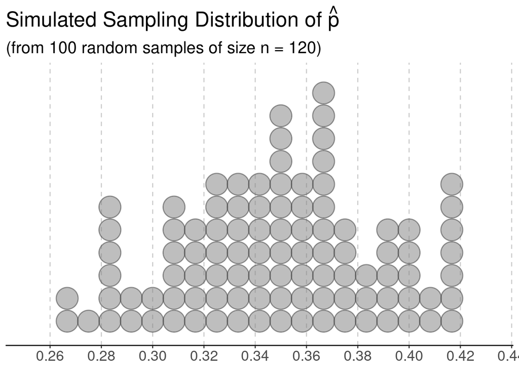

```r
simProportions(proportionMA, 120)
```

*Answer:* Each dot in the distribution above represents each sample proportion or number of movies rated TV-MA out of the total sample size of each being 120 Netflix movies.

> 3. Based on your plot from Exercise 2, what sample proportion values would you consider unlikely to occur by random chance? Explain your answer.

*Answer:* Since the plot represents a distribution that is approximately normal, we can use the empirical rule to determine the number of sample proportions that lie inside three standard deviations to the mean of 0.341. Looking at the distribution, it seems that values of proportions of 0.22 and less and proportions of 0.44 or more seem to lie outside three standard deviations to the mean or outside 99.7% of the distribution, thus indicating that those values are least likely to occur by chance.

> 4. As described in the background (above the Lab Exercises), we wish to assess if the populaton proportion of 2020 Netflix movies that are rated TV-MA has increased when compared to the value for 2015 Netflix movies computed in Exercise 1. Use notation to state the null and alternative hypothesis. Then, define the appropriate parameter of interest in context.

*Answer:* H0: *p* *=* *0.341* vs Ha: *p* *>* *0.341*

*Answer:* Where *p* represents *the population (true) proportion of 2020 Netflix movies that are rated TV-MA.*

> 5. Using the `movies_2020_sample` data set (**note: this is a different data set than the one used in Exercise 1!**), create a frequency table that summarizes the variable for content rating. In the second code chunk, use R as a calculator to compute the proportion of movies rated TV-MA. Below this, *fully* define your computed value. Be specific and include context.

```r
table(movies_2020_sample$rating)
```

```
##
##    PG PG-13     R TV-14  TV-G TV-MA TV-PG  TV-Y TV-Y7
##     3     7     8    25     7    50    11     5     4
```

```r
proportionMAsample = 50 / (3+7+8+25+7+50+11+5+4)
print(proportionMAsample)
```

```
## [1] 0.4166667
```

*Answer:* The proportion of 0.417 is the proportion of the number of TV_MA rated movies out of all movies in the sample of data for movies from 2020 on Netflix.

> 6. Using the `simProportions()` function (with the `threshold` and `alternative` arguments specified), simulate the hypothesis test (and corresponding p-value). Approximately, where is the center of this distribution. In 1 - 2 sentences, explain why this center is used to simulate/run the hypothesis test.

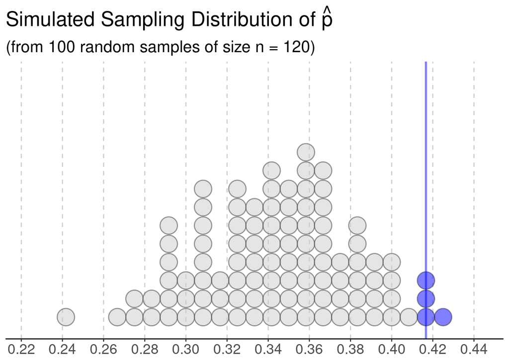

```r
simProportions(proportionMA, 120, threshold = proportionMAsample, alternative = "greater")
```

*Answer:* The center of this distribution is approximately at the proportion of 0.341. We use this proportion to estimate the center instead of the 2020 movies sample proportion because our null hypothesis assumes that the true proportion of movies in 2020 that are TV-MA is 0.341, and we assume the null hypothesis to be true for the distribution in order to compare the sample proportion in relation to the null proportion.

> 7. Using the `onePopPropHT()` function, run the hypothesis test. Based on your results, provide an evaluation and conlusion within the context of the problem.

```r
onePopPropHT(x = 50, n = 120, p0 = proportionMA, alternative = "greater")
```

```
## $phat
## [1] 0.4166667
##
## $test.stat
## [1] 1.750752
##
## $p.value
## [1] 0.03999428
```

*Evaluation:* Assuming that the proportion of Netflix movies in 2020 that are rated TV-MA out of all 2020 Netflix movies is 0.341 or 34.1%, the probability of getting test statistic of 1.75 (meaning falling 1.75 null standard deviations above the null center value of 0.341) or greater is 0.040 or 4.0% using a random sample of 120 Netflix movies from 2020.

*Conclusion:* Based on the data, we have strong evidence against the null hypothesis (that the true population proportion of all 2020 Netflix movies that are rated TV-MA is 0.341) and for the alternative hypothesis that the true population proportion of all 2020 Netflix movies that are rated TV-MA is greater than the null proportion of 0.341.

### Dive Deeper Questions

After completing the lab exercises above, complete the following Dive Deeper questions. Remember, these questions are worth 3 points each and are graded for correctness.

> **1.** Suppose you were to collect a *new* random sample of 2020 Netflix movies, but you were able to collect data for *240* movies (twice the sample size used above). If you found the *same sample proportion* (as you had in Exercise 5), would you expect the corresponding p-value to increase, decrease, or stay the same (as compared to the p-value from Exercise 7)? Explain your answer.

*Answer:* If we had collected the data for 240 movies instead of 120, the standard deviation of this distribution that we would calculate would become smaller (standard deviation of the normal distribution for a p-hat value is sqrt((p-hat - p-null) / sample size (n))). Since the standard deviation is smaller, we calculated the z-score or standardized score value to be larger because standard value = (p-hat - p-null) / standard deviation thus if standard deviation decreases the standard score increases. If the standardized score increases, the p-value or the probability of the sample proportion being greater than the p-hat value will decrease because larger standardized scores show more standard deviations away from the mean or center of the distribution, correlating to less probability of obtaining that sample proportion. Therefore, if the sample size increases, the corresponding p-value will decrease if p-hat remains the same.

> **2.** Suppose you wish to run a similar test to evaluate if the population proportion of movies that are *rated R has increased* from a value of 0.17 (17%). After collecting a sample of movies, you find the sample proportion to be 0.07 (7%). Would you expect to find a small p-value or a large p-value based on these sample results? Explain your answer.

*Answer:* For these results, we would expect to find that the p-value is large if the sample proportion is 7% as compared to the assumed population proportion of 17%. This is because we are checking to see if the proportion of rated R movies has increased, but the sample proportion we find is 10% less than the null hypothesized population proportion of 17%. This means that the standardized score of the sample proportion will be less than the mean score because we are decreasing from the center of the proposed distribution. This means the z-score will be negative, and we are looking for the number of sample proportions that would fall above the current z-score we have, so we would get all sample proportions from the center to the right end of the distribution, indicating that our p-value or the probability of getting a sample proportion higher than 7% would be greater than 50%, causing the p-value to be large.

### Submission Instructions

Once you have finished, follow the instructions below to submit your work.

1. At the top of the document, update the `author` field. *Do not change anything else at the top of the document.*
2. Click the Knit button to create an HTML file of your work.
3. In the Files pane (bottom right window), check the box next to `lab04_assignment.html`.
4. In the Files pane, click on the gear icon (More) and select “Export…”
5. Do not change the file name (`lab04_assignment.html`). Click Download and save the file to your computer.
6. On the Stats 250 Canvas site, navigate to the Lab 4 assignment.
7. Upload your saved `lab04_assignment.html` file.
8. Click “Submit Assignment”. Congratulations, you are done with Lab 4!